# LangCog Permutation Analysis Test

```r
knitr::opts_chunk$set(warning=F, cache=T, message=F)
```

Load eye movement data from eyetrackingR package.

```r
glimpse(d)
```

```
Observations: 195,912
Variables: 15
$ ParticipantName       <fct> ANCAT139, ANCAT139, ANCAT139, ANCAT139, ANCAT139, ANCAT139, ANCAT139, ANCA...
$ Sex                   <fct> F, F, F, F, F, F, F, F, F, F, F, F, F, F, F, F, F, F, F, F, F, F, F, F, F,...
$ Age                   <dbl> 21.86, 21.86, 21.86, 21.86, 21.86, 21.86, 21.86, 21.86, 21.86, 21.86, 21.8...
$ TrialNum              <dbl> 1, 1, 1, 1, 1, 1, 1, 1, 1, 1, 1, 1, 1, 1, 1, 1, 1, 1, 1, 1, 1, 1, 1, 1, 1,...
$ Trial                 <fct> FamiliarBottle, FamiliarBottle, FamiliarBottle, FamiliarBottle, FamiliarBo...
$ TimeFromTrialOnset    <int> 0, 17, 33, 50, 67, 83, 100, 117, 133, 150, 167, 183, 200, 217, 233, 250, 2...
$ Subphase              <fct> Preview, Preview, Preview, Preview, Preview, Preview, Preview, Preview, Pr...
$ TimeFromSubphaseOnset <int> 0, 17, 33, 50, 67, 83, 100, 117, 133, 150, 167, 183, 200, 217, 233, 250, 2...
$ AOI                   <fct> TrackLoss, TrackLoss, TrackLoss, TrackLoss, TrackLoss, TrackLoss, TrackLos...
$ Animate               <lgl> NA, NA, NA, NA, NA, NA, NA, NA, NA, NA, NA, NA, NA, NA, NA, NA, NA, NA, NA...
$ Inanimate             <lgl> NA, NA, NA, NA, NA, NA, NA, NA, NA, NA, NA, NA, NA, NA, NA, NA, NA, NA, NA...
$ TrackLoss             <lgl> TRUE, TRUE, TRUE, TRUE, TRUE, TRUE, TRUE, TRUE, TRUE, TRUE, TRUE, TRUE, TR...
$ MCDI_Total            <int> 47, 47, 47, 47, 47, 47, 47, 47, 47, 47, 47, 47, 47, 47, 47, 47, 47, 47, 47...
$ MCDI_Nouns            <int> 29, 29, 29, 29, 29, 29, 29, 29, 29, 29, 29, 29, 29, 29, 29, 29, 29, 29, 29...
$ MCDI_Verbs            <int> 8, 8, 8, 8, 8, 8, 8, 8, 8, 8, 8, 8, 8, 8, 8, 8, 8, 8, 8, 8, 8, 8, 8, 8, 8,...
```

```r
data <- make_eyetrackingr_data(d,
                       participant_column = "ParticipantName",
                       trial_column = "Trial",
                       time_column = "TimeFromTrialOnset",
                       trackloss_column = "TrackLoss",
                       aoi_columns = c('Animate','Inanimate'),
                       treat_non_aoi_looks_as_missing = TRUE
                )
# subset to response window post word-onset
response_window <- subset_by_window(data,
                                    window_start_time = 15500,
                                    window_end_time = 21000,
                                    rezero = FALSE)
```

```
Avg. window length in new data will be 5500
```

```r
# analyze amount of trackloss by subjects and trials
(trackloss <- trackloss_analysis(data = response_window))
```

```
# A tibble: 155 x 6
   ParticipantName Trial          Samples TracklossSamples TracklossForTrial TracklossForParticipant
   <fct>           <fct>            <dbl>            <dbl>             <dbl>                   <dbl>
 1 ANCAT139        FamiliarBottle     330              161            0.488                   0.488
 2 ANCAT18         FamiliarBird       330               74            0.224                   0.319
 3 ANCAT18         FamiliarBottle     330               43            0.130                   0.319
 4 ANCAT18         FamiliarCow        330              159            0.482                   0.319
 5 ANCAT18         FamiliarDog        330               95            0.288                   0.319
 6 ANCAT18         FamiliarHorse      330              165            0.5                     0.319
 7 ANCAT18         FamiliarSpoon      330               95            0.288                   0.319
 8 ANCAT22         FamiliarBird       330               14            0.0424                  0.0588
 9 ANCAT22         FamiliarBottle     330                8            0.0242                  0.0588
10 ANCAT22         FamiliarDog        330               55            0.167                   0.0588
# ... with 145 more rows
```

```r
# remove trials with > 25% of trackloss
response_window_clean <- clean_by_trackloss(data = response_window,
                                            trial_prop_thresh = .25)
```

```
Performing Trackloss Analysis...
Will exclude trials whose trackloss proportion is greater than : 0.25
    ...removed  33  trials.
```

Create Target condition column

```r
# create Target condition column
response_window_clean$Target <- as.factor( ifelse(test = grepl('(Spoon|Bottle)', response_window_clean$Trial),
                                       yes = 'Inanimate',
                                       no  = 'Animate') )
```

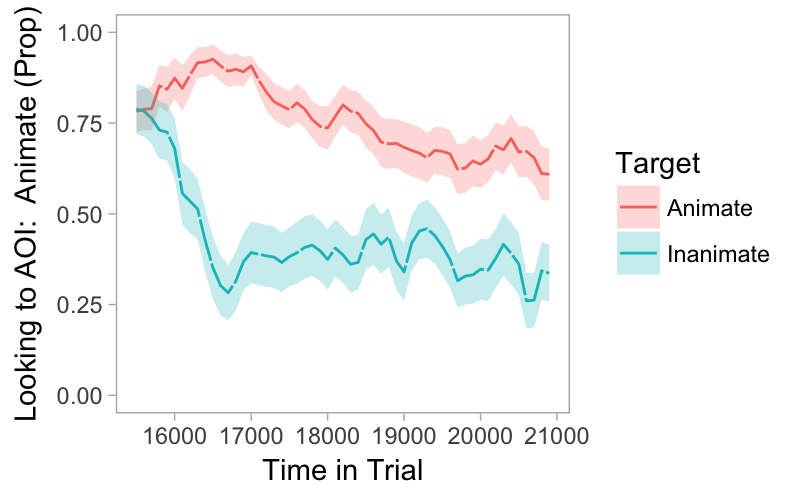

```r
response_time <- make_time_sequence_data(response_window_clean,
                                  time_bin_size = 100,
                                  predictor_columns = c("Target"),
                                  aois = "Animate",
                                  summarize_by = "ParticipantName" )
# visualize timecourse
plot(response_time, predictor_column = "Target") +
  theme_light() +
  coord_cartesian(ylim = c(0,1))
```

## Do cluster-based permutation analysis

```r
d_filt_ts <- response_time %>%
  select(ParticipantName, TimeBin, Prop, Target) %>%
  as_tibble()
```

filter NAs

```r
d_filt_ts %<>% filter(!is.na(Prop))
```

Plot data to make sure we get something that looks like the vignette.

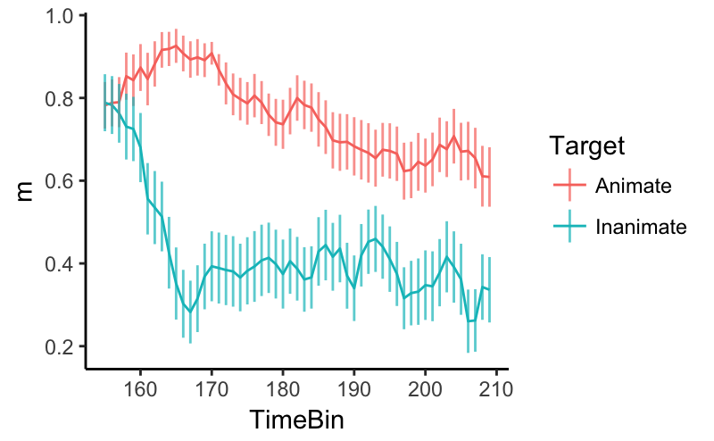

```r
ss <- d_filt_ts %>%
  group_by(ParticipantName, Target, TimeBin) %>%
  summarise(ss_m = mean(Prop, na.rm = T))
ms <- ss %>%
  group_by(Target, TimeBin) %>%
  summarise(n = n(),
            m = mean(ss_m, na.rm = T), stdev = sd(ss_m)) %>%
  mutate(se = stdev / sqrt(n),
         ci = 2 * se)
ms %>%
  ggplot(aes(x = TimeBin, y = m, color = Target)) +
  geom_line() +
  geom_linerange(aes(ymin = m - se, ymax = m + se), alpha = 0.7) +
  #geom_linerange(aes(ymin = m - ci, ymax = m + ci), alpha = 0.7) +
  theme(legend.position = "top") +
  theme_classic()
```

Rename stuff to match my code

```r
d_filt <- ss %>%
  rename(trial_type = Target,
         Bin = TimeBin,
         Participant = ParticipantName)
```

Set t threshold

```r
num_sub = length(unique((response_window_clean$ParticipantName)))
threshold_t = qt(p = 1 - .05/2, df = num_sub-1) # pick threshold t based on alpha = .05 two tailed
```

Nest the data by time bin

```r
by_bin <- d_filt %>%
  group_by(Bin) %>%
  nest()
```

```r
bin_cut_point <- d_filt %>%
  group_by(trial_type) %>%
  summarise(max_bin = max(Bin)) %>%
  pull(max_bin) %>%
  min()
by_bin %<>% filter(Bin <= bin_cut_point)
```

1. Map the t-test to each time bin and store it as a variable in the by_bin data frame.

```r
by_bin %<>% mutate(model = map(data, run_t_test, alternative = "two.sided"))
```

2. Take the time-bins whose test passed the threshold statistic (e.g., t > 2), and group them by adjacency. We will call these time-clusters. To do this, we extract the t-stats and their bin numbers and filter by the threshold defined above.

```r
# get t-stats for each model
t_df <- by_bin %>%
  mutate(glance = map(model, broom::glance)) %>%
  unnest(glance, .drop = TRUE) %>%
  select(Bin, statistic, p.value)
# filter by t threshold
t_df_filt <- t_df %>% filter(statistic >= threshold_t)
t_df_filt
```

```
# A tibble: 47 x 3
     Bin statistic      p.value
   <dbl>     <dbl>        <dbl>
 1   161      2.70 0.00963
 2   162      3.34 0.00172
 3   163      4.26 0.000127
 4   164      5.13 0.00000931
 5   165      5.96 0.000000707
 6   166      6.52 0.0000000933
 7   167      6.96 0.0000000170
 8   168      6.34 0.000000152
 9   169      5.86 0.000000827
10   170      5.79 0.00000213
# ... with 37 more rows
```

3. For each time-cluster, calculate the sum of the statistics for the time-bins inside it.

The technical challenge here is to figure out how to define the clusters based on the Bin vector.

```r
t_df_filt %<>% define_clusters()
t_df_filt
```

```
# A tibble: 47 x 4
     Bin statistic      p.value cluster
   <dbl>     <dbl>        <dbl> <chr>
 1   161      2.70 0.00963      cluster_1
 2   162      3.34 0.00172      cluster_1
 3   163      4.26 0.000127     cluster_1
 4   164      5.13 0.00000931   cluster_1
 5   165      5.96 0.000000707  cluster_1
 6   166      6.52 0.0000000933 cluster_1
 7   167      6.96 0.0000000170 cluster_1
 8   168      6.34 0.000000152  cluster_1
 9   169      5.86 0.000000827  cluster_1
10   170      5.79 0.00000213   cluster_1
# ... with 37 more rows
```

4. Next, we calculate the sum of the statistics for the time-bins inside each cluster.

```r
observed_t_vals <- t_df_filt %>%
  group_by(cluster) %>%
  summarise(sum_t = sum(statistic))
observed_t_vals
```

```
# A tibble: 2 x 2
  cluster   sum_t
  <chr>     <dbl>
1 cluster_1 130.
2 cluster_2  45.9
```

Take the largest of the cluster-level statistics and store it for later. This is the t-value that we will use to compare against our null distribution generated by the permutations that we will create in the next part of the program.

```r
largest_t <- observed_t_vals %>% pull(sum_t) %>% max()
largest_t
```

```
[1] 130.0912
```

### Generate null distribution by shuffling data

We will take our data and randomly shuffle it, assigning participants randomly to each condition. Then we will perform steps (1)-(3) on the shuffled dataset and save the biggest sum-statistic from each permutation analysis.

A note from the supplemental materials in Cesana-Arlotti et. al., (2018):

> To evaluate the significance of the test, we recomputed the same analysis on 1000 sets of random permutations. The permutations were computed by randomly assigning the participants to the condition labels (Inference/No Inference), taking care to maintain the N of the two conditions identical to the N available for the original data.

So we create a list of data frames. Each data frame is a permuted dataset.

```r
# global variables for setting up shuffling and
set.seed(7)
n_permutations <- 1000
permuted_dfs <-  vector("list", length(1:n_permutations))
system.time(
  for (n_sim in 1:n_permutations) {
    permuted_dfs[[n_sim]] <- permute_data(d_filt)
  }
)
```

```
   user  system elapsed
  5.601   0.063   5.702
```

```r
system.time(
  null_dist_1 <- map(permuted_dfs, t_test_by_bin, alternative = "two.sided", bin_cut = bin_cut_point)
)
```

```
   user  system elapsed
 78.268   0.475  79.056
```

```r
system.time(
 null_dist_2 <- map(null_dist_1, extract_t, t_threshold = threshold_t, alternative = "two.sided")
)
```

```
   user  system elapsed
 69.031   0.397  70.771
```

Then, we make clusters for each filtered data frame of Bins that have above-threshold t-values. **KM: What to do if there weren’t any significant t-stats during the by_bin pass? Right now, I’m just ignoring these simulations.**

```r
system.time(
  null_dist_3 <- map(null_dist_2, define_clusters)
)
```

```
   user  system elapsed
  0.745   0.008   0.765
```

Then, we sum the t-stats for each cluster and store the largest value for each simulation. **KM: What to do if there weren’t any significant t-stats during the by_bin pass? Right now, I’m just ignoring these simulations.**

```r
system.time(
  null_dist_4 <- map(null_dist_3, sum_t_stats) %>% unlist() %>% data.frame(null_t = .)
)
```

```
   user  system elapsed
  1.590   0.014   1.630
```

We can visualize this null distribution along with our sample sum-statistic.

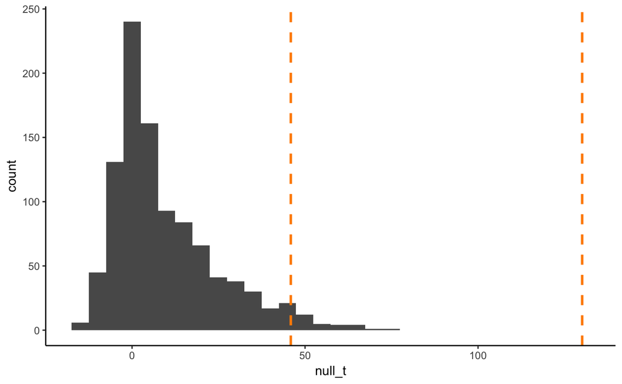

```r
null_dist_4 %>%
  ggplot(aes(x = null_t)) +
  geom_histogram() +
  geom_vline(aes(xintercept = sum_t),
             data = observed_t_vals,
             color = "darkorange",
             linetype = "dashed",
             size = 1) +
  theme_classic()
```

```r
t_value_to_test
```

```
[1] 45.88477
```